# $K$NN

Author

Kaiona Apio

Published

February 10, 2025

**Abstract:**

This is a technical blog post of **both** an HTML file *and* [.qmd file](https://kaionaa.github.io/DATA505/KNN.html) hosted on GitHub pages.

# 1. Setup

```r
library(tidyverse)
library(caret)
library(fastDummies)
library(class)
wine <- readRDS(gzcon(url("https://github.com/cd-public/D505/raw/master/dat/pinot.rds")))
```

## 2. $K$NN Concepts

> When using a $K$ Nearest Neighbors algorithm, choosing a larger value for K results in a larger group of ‘neighbors’ being included in the prediction. I would assume that a larger K would increase the accuracy of a prediction, or at least increase the data analyzed to generate said prediction.

## 3. Feature Engineering

1. Create a version of the year column that is a *factor* (instead of numeric).
2. Create dummy variables that indicate the presence of “cherry”, “chocolate” and “earth” in the description.
- Take care to handle upper and lower case characters.
3. Create 3 new features that represent the interaction between *time* and the cherry, chocolate and earth indicators.
4. Remove the description column from the data.

```r
wine <- wine %>% #formatting upper & lowercase
  rename_all(funs(tolower(.))) %>%
  rename_all(funs(str_replace_all(., "-", "_"))) %>%
  rename_all(funs(str_replace_all(., " ", "_")))

wine <- wine %>% #changing variables
  mutate(year = as.factor(year),
         note_cherry = str_detect(description,"cherry"),
         note_chocolate = str_detect(description,"chocolate"),
         note_earth = str_detect(description,"earth"))%>%
  select(-description)%>%
  mutate(time_cherry = as.numeric(year) * note_cherry,
         time_chocolate = as.numeric(year) * note_chocolate,
         time_earth = as.numeric(year) * note_earth)

head(wine)
```

```
  id   province price points year note_cherry note_chocolate note_earth
1  1     Oregon    65     87 2012       FALSE          FALSE       TRUE
2  2     Oregon    20     87 2013       FALSE           TRUE      FALSE
3  3 California    69     87 2011       FALSE          FALSE       TRUE
4  4     Oregon    50     86 2010       FALSE          FALSE      FALSE
5  5     Oregon    22     86 2009       FALSE          FALSE       TRUE
6  6     Oregon    25     86 2015       FALSE          FALSE      FALSE
  time_cherry time_chocolate time_earth
1           0              0         17
2           0             18          0
3           0              0         16
4           0              0          0
5           0              0         14
6           0              0          0
```

## 4. Preprocessing

1. Preprocess the dataframe from the previous code block using BoxCox, centering and scaling of the numeric features

```r
wine %>%
  preProcess(method = c("BoxCox","center","scale")) %>%
  predict(wine) %>%
  head()
```

```
         id   province      price    points year note_cherry note_chocolate
1 -2.206642     Oregon  0.7146905 -1.033841 2012       FALSE          FALSE
2 -2.202427     Oregon -1.4139991 -1.033841 2013       FALSE           TRUE
3 -2.198830 California  0.8225454 -1.033841 2011       FALSE          FALSE
4 -2.195581     Oregon  0.2408520 -1.367723 2010       FALSE          FALSE
5 -2.192571     Oregon -1.2418658 -1.367723 2009       FALSE          FALSE
6 -2.189736     Oregon -1.0109945 -1.367723 2015       FALSE          FALSE
  note_earth time_cherry time_chocolate time_earth
1       TRUE  -0.8056391     -0.2605341  2.2407208
2      FALSE  -0.8056391      4.0372528 -0.4333603
3       TRUE  -0.8056391     -0.2605341  2.0834219
4      FALSE  -0.8056391     -0.2605341 -0.4333603
5       TRUE  -0.8056391     -0.2605341  1.7688241
6      FALSE  -0.8056391     -0.2605341 -0.4333603
```

2. Create dummy variables for the `year` factor column

```r
wino <- wine %>%
  dummy_cols(
    select_columns = "year",
    remove_most_frequent_dummy = TRUE,
    remove_selected_columns = TRUE
  )
```

## 5. Running $K$NN

1. Split the dataframe into an 80/20 training and test set

```r
set.seed(505)
wine_index <- createDataPartition(wino$province, p = 0.8, list = FALSE)
train <- wino[ wine_index, ]
test <- wino[-wine_index, ]
```

2. Use Caret to run a $K$NN model that uses our engineered features to predict province
- use 5-fold cross validated subsampling
- allow Caret to try 15 different values for $K$

```r
fit <- train(province ~ .,
             data = train,
             method = "knn",
             tuneLength = 15,
             metric = "Kappa",
             trControl = trainControl(number = 5, method = "cv"))
```

3. Display the confusion matrix on the test data

```r
print(confusionMatrix(predict(fit, test),factor(test$province)))
```

```
Confusion Matrix and Statistics

                   Reference
Prediction          Burgundy California Casablanca_Valley Marlborough New_York
  Burgundy                92         46                 1           5        1
  California              92        511                10          20       14
  Casablanca_Valley        0          4                 0           1        0
  Marlborough              1         13                 1           3        1
  New_York                 0          3                 0           0        1
  Oregon                  53        214                14          16        9
                   Reference
Prediction          Oregon
  Burgundy              43
  California           283
  Casablanca_Valley      1
  Marlborough            8
  New_York               3
  Oregon               209

Overall Statistics

               Accuracy : 0.4877
                 95% CI : (0.4635, 0.512)
    No Information Rate : 0.4728
    P-Value [Acc > NIR] : 0.1152

                  Kappa : 0.1738

 Mcnemar's Test P-Value : NA

Statistics by Class:

                     Class: Burgundy Class: California Class: Casablanca_Valley
Sensitivity                  0.38655            0.6460                 0.000000
Specificity                  0.93310            0.5249                 0.996357
Pos Pred Value               0.48936            0.5495                 0.000000
Neg Pred Value               0.90168            0.6231                 0.984403
Prevalence                   0.14226            0.4728                 0.015541
Detection Rate               0.05499            0.3054                 0.000000
Detection Prevalence         0.11237            0.5559                 0.003586
Balanced Accuracy            0.65983            0.5855                 0.498179
                     Class: Marlborough Class: New_York Class: Oregon
Sensitivity                    0.066667       0.0384615        0.3821
Specificity                    0.985258       0.9963570        0.7282
Pos Pred Value                 0.111111       0.1428571        0.4058
Neg Pred Value                 0.974484       0.9849940        0.7081
Prevalence                     0.026898       0.0155409        0.3270
Detection Rate                 0.001793       0.0005977        0.1249
Detection Prevalence           0.016139       0.0041841        0.3078
Balanced Accuracy              0.525962       0.5174093        0.5552
```

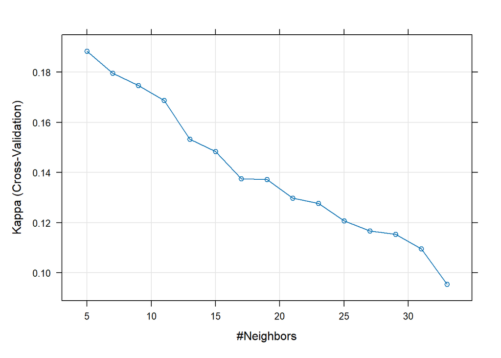

```r
plot(fit, metric="Kappa")
```

## 6. Kappa

How do we determine whether a Kappa value represents a good, bad or some other outcome?

> The Kappa value for this problem is 0.1738, which is not good, one could even say bad.

## 7. Improvement

How can we interpret the confusion matrix, and how can we improve in our predictions?

> In terms of this confusion matrix, we could assume the model is best at predicting California (511 correct predictions) and Oregon (209 correct predictions). However, both California and Oregon have high rates of false positives and the model is pretty poor at predicting the Casablanca Valley, Marlborough, and New York classes.

> To improve the model, I would look at a more important feature while engineering. I love a good PCA, so that would help display definite groupings within the data, and ideally help highlight more important features. Another way to improve the model, would be focusing on more balanced groups, as we know, this data set has significant imbalance around province representation, so weights are a solution.